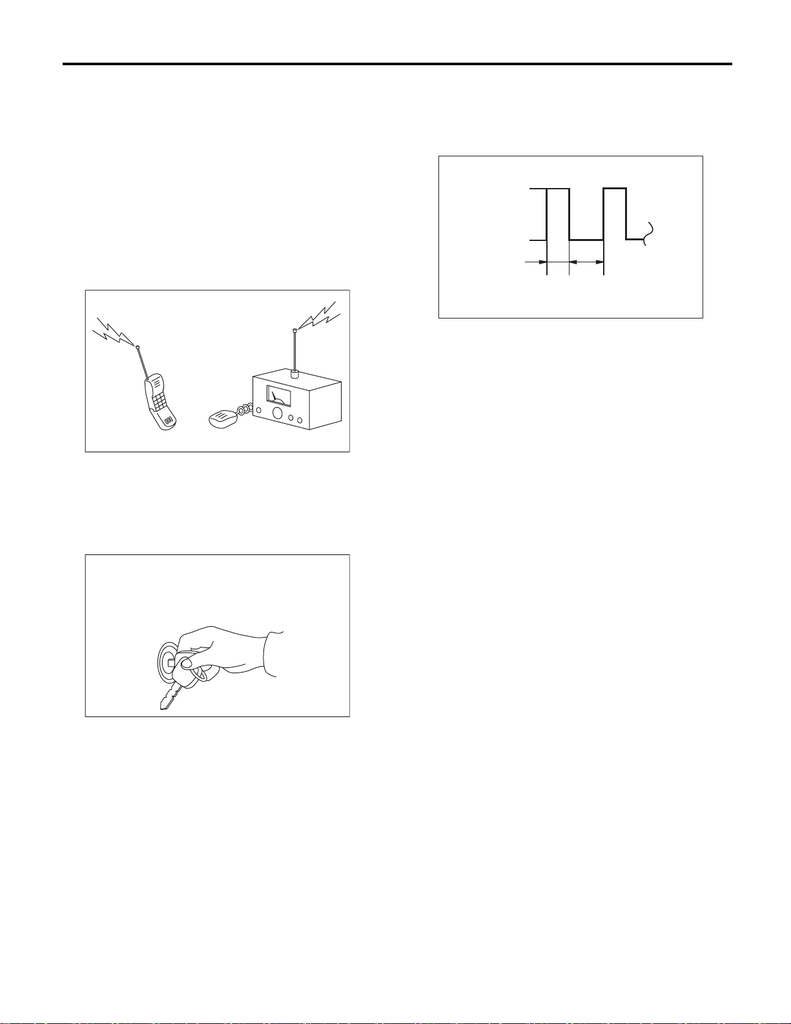

General Description

IMMOBILIZER (DIAGNOSTICS)

2. General Description

A: CAUTION

CAUTION:

• Do not use the electrical test equipment on

the airbag system wiring harnesses and con-

nector circuits.

• Be careful not to damage the airbag system

wiring harness.

• While diagnostic items are being checked, do

not operate radios, portable telephones, etc.

which emit electromagnetic waves near or in-

side the vehicle.

• When turning the ignition switch to ON or

OFF while diagnostic items are being checked,

do not allow keys with different ID codes close

to the ignition switch. If the ignition key is on a

key holder, remove it from the key holder be-

fore performing diagnoses.

• When repeatedly turning the ignition switch

to ON or OFF while diagnostic items are being

checked, it should be switched in cycles of

“ON” for at least 5 seconds → “OFF” for at least

8 seconds.

• If the engine fails to start with a registered ig-

nition key, detach the ignition key from ignition

switch and wait for approx. 1 second until secu-

rity indicator light begins to flash. And then

start the engine again.

• Before performing the diagnostics, obtain all

keys for the vehicle from the owner.

• Do not register a body integrated unit already

registered to another vehicle to diagnose fail-

ures or inspect functions.

NG

IM-00211

IM-00212

(1) Ignition switch position

(2) Sec.

IM-00003

ON

OFF

(2)

(1)

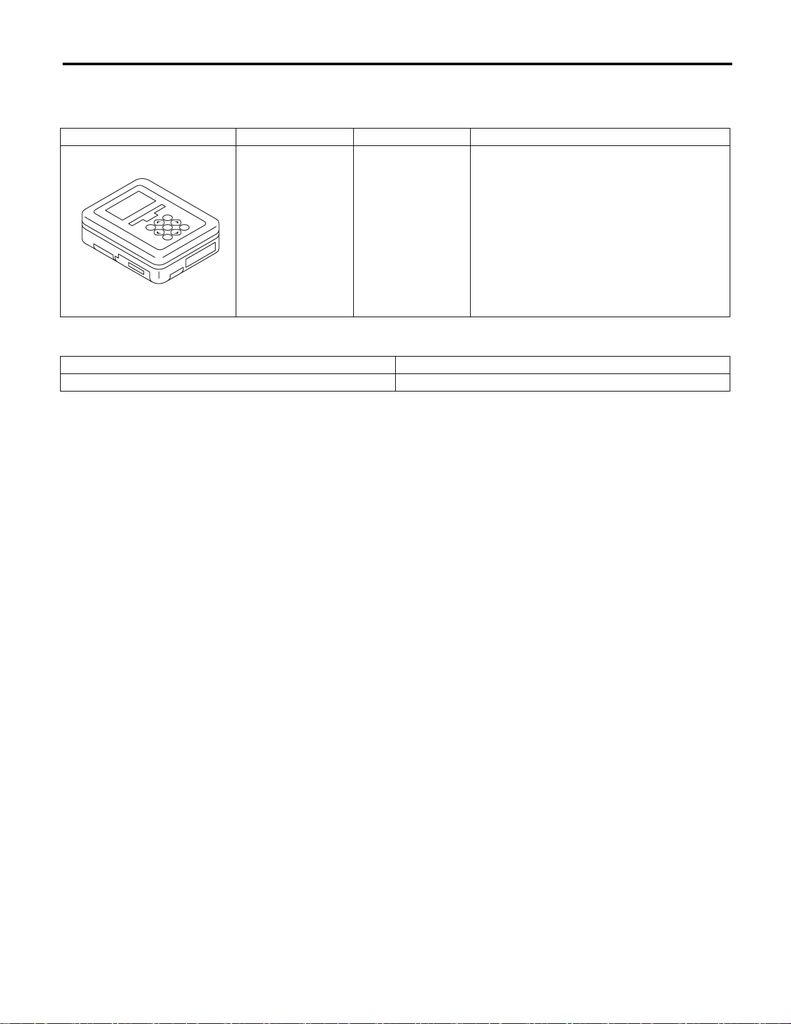

General Description

IMMOBILIZER (DIAGNOSTICS)

B: PREPARATION TOOL

1. SPECIAL TOOL

2. GENERAL TOOL

ILLUSTRATION TOOL NUMBER DESCRIPTION REMARKS

1B022XU0 SUBARU SELECT

MONITOR III KIT

Used for troubleshooting the electrical system.

TOOL NAME REMARKS

Circuit tester Used for measuring resistance, voltage and current.

ST1B022XU0